# P8108 Group 2 Survival Analysis Project

Yiming Zhao (yz3955)

Wenshan Qu (wq2160)

Tucker Morgan (tlm2152)

Junzhe Shao (js5959)

Benjamin Goebel (bpg2118)

2022-12-1

# Introduction

Breast cancer is a leading cause of cancer-related morbidity and mortality worldwide, and the choice of treatment can have a significant impact on patient outcomes. Hormone therapy and chemotherapy are two common treatment options for breast cancer, but their effectiveness in improving survival may vary depending on the specific characteristics of the patient and the tumor and there is plenty of literature comparing their effectiveness.

In this study, we aim to evaluate the effectiveness of hormone therapy and chemotherapy in improving breast cancer survival for our target population using the data from the Rotterdam tumor bank. Specifically, we will examine the treatment effect and taking into account various patient and tumor characteristics that may be the confounders of the treatment.

In addition to evaluating the effectiveness of different treatments, we will also compare the performance of non-parametric modeling approaches, such as random forests, to that of semi-parametric approaches, such as the Cox proportional hazards model, in predicting breast cancer survival. Understanding the performance of these different modeling approaches can inform the selection of the most appropriate method for predicting breast cancer survival in different settings.

# Exploratory Data Analysis

### Table 1: Distribution of covariates between hormone therapy treatment groups

|  | 0 (N=2643) | 1 (N=339) | Total (N=2982) | p value |
| --- | --- | --- | --- | --- |
| **age** |  |  |  | < 0.001 |
| Mean | 54.098 | 62.549 | 55.058 |  |
| **meno** |  |  |  | < 0.001 |
| Mean | 0.519 | 0.879 | 0.560 |  |
| **size** |  |  |  | < 0.001 |
| <=20 | 1283 (48.5%) | 104 (30.7%) | 1387 (46.5%) |  |
| 20-50 | 1119 (42.3%) | 172 (50.7%) | 1291 (43.3%) |  |
| >50 | 241 (9.1%) | 63 (18.6%) | 304 (10.2%) |  |
| **grade** |  |  |  | < 0.001 |
| Mean | 2.722 | 2.826 | 2.734 |  |
| **nodes** |  |  |  | < 0.001 |
| Mean | 2.327 | 5.720 | 2.712 |  |
| **pgr** |  |  |  | < 0.001 |
| Mean | 168.706 | 108.233 | 161.831 |  |
| **er** |  |  |  | 0.069 |
| Mean | 164.792 | 180.608 | 166.590 |  |
| **chemo** |  |  |  | < 0.001 |
| 0 | 2091 (79.1%) | 311 (91.7%) | 2402 (80.5%) |  |
| 1 | 552 (20.9%) | 28 (8.3%) | 580 (19.5%) |  |

### Table 2: Distribution of covariates between chemotherapy treatment groups

|  | 0 (N=2402) | 1 (N=580) | Total (N=2982) | p value |
| --- | --- | --- | --- | --- |
| **age** |  |  |  | < 0.001 |
| Mean | 57.560 | 44.698 | 55.058 |  |
| **meno** |  |  |  | < 0.001 |
| Mean | 0.658 | 0.153 | 0.560 |  |
| **size** |  |  |  | 0.002 |
| <=20 | 1148 (47.8%) | 239 (41.2%) | 1387 (46.5%) |  |
| 20-50 | 1028 (42.8%) | 263 (45.3%) | 1291 (43.3%) |  |
| >50 | 226 (9.4%) | 78 (13.4%) | 304 (10.2%) |  |
| **grade** |  |  |  | 0.964 |
| Mean | 2.734 | 2.734 | 2.734 |  |
| **nodes** |  |  |  | < 0.001 |
| Mean | 2.353 | 4.198 | 2.712 |  |
| **pgr** |  |  |  | 0.002 |
| Mean | 157.556 | 179.536 | 161.831 |  |
| **er** |  |  |  | < 0.001 |
| Mean | 183.599 | 96.148 | 166.590 |  |
| **hormon** |  |  |  | < 0.001 |
| 0 | 2091 (87.1%) | 552 (95.2%) | 2643 (88.6%) |  |
| 1 | 311 (12.9%) | 28 (4.8%) | 339 (11.4%) |  |

### Figure 1: Correlation of variables in Rotterdam data set

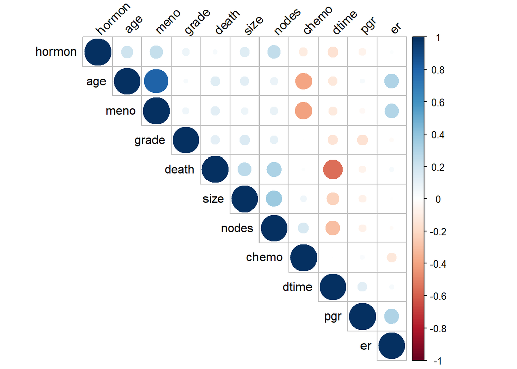

As a correlation analysis was conducted, the correlation matrix indicates that premenopausal women and young women are moderately correlated to taking chemotherapy. A highly positive correlation between menopausal status and age, and two moderately negative correlations between age and chemotherapy, menopausal status and chemotherapy correspond to clinical practice.

# Methods

The dataset of interest for this analysis comes from the Rotterdam tumor bank, including data from 2982 breast cancer patients. Follow up time for patients varied from just 1 month to as long as 231 months. Several prognostic variables are recorded including year of surgery, age at surgery, menopausal status (pre- or post-), tumor size (mm), differentiation grade, number of positive lymph nodes, progesterone receptors (fmol/l), estrogen receptors (fmol/l), and indicators for hormonal treatment and chemotherapy treatment. The outcome considered in this analysis was patient death. The censoring mechanism is right censoring, which we assume to be non-informative.

## Log-rank test

To investigate our research questions, we first use a non-parametric log-rank test, which makes no distributional assumptions about our data. The log-rank test compares differences between expected and observed events at each event time point, $k$, to derive the following test statistics:
$$L
= \sum_{i = 1}^k (d_{0i} - e_{0i});$$
$$var(L) = \sum_{i=1}^k \frac{n_{0i}n_{1i}d_i(n_i -
d_i)}{n_i^2 (n_i - 1)};$$
where $L/\sqrt{var(L)} \sim N(0,1)$. A significant result from the log-rank test indicates a statistically significant difference between the two groups. Notably, the log-rank test does not allow us to adjust for covariates or prognostic variables.

## Regularized Cox Proportional Hazard Model

As a further step in this analysis, we consider the Cox Proportional Hazard (Cox PH) model, which allows us to model the hazard ratio based on covariates to understand their impact on the survival function. The Cox PH typically takes the form:
$$h(t|Z = z)
= h_0(t)e^{\beta'z}.$$

In this application, we use the Least Absolute Shrinkage and Selection Operator (LASSO), an application of the $\ell_1$ norm regularization penalty. In the Cox PH framework, this penalty term takes the form of:
$$\lambda \sum |\beta_i|$$
where $\lambda$ represents our penalty coefficient. This penalty helps to avoid over-fitting of our data in an effort to improve the generalizability of our predictive model in different settings. The algorithm used here in `glmnet` uses the Breslow approximation to handle ties. For more details on the derivation of this term and the algorithm used to fit the penalized Cox PH model, see Simon et al. (2011).

## Random Survival Forest

The survival tree and the corresponding random survival forest (RSF) are highly favorable non-parametric methods when studying survival data. Generally, for a single survival tree, it will assign subjects to groups based on certain splitting rules regarding their covariates, and the subjects in each group will share a similar survival behavior. This model, being non-parametric, makes no additional assumptions. However, we continue to assume that the censoring is non-informative.

## Brier score

We compare the Cox proportional-hazards model with the random survival forest by calculating the Brier score for each model on the test data set. The formula for the Brier score is as follows.
$$\begin{align*}
BS = \frac{1}{n} \sum_{i=1}^n (p_i - o_i)^2
\end{align*}$$
The Brier score is used to evaluate the accuracy of probabilistic predictions from a model; its value ranges from 0 to 1 with 0 being perfect and 1 being the opposite. We calculate the Brier score using the test data set. For each observation in the test data set, predictions are made at the observed time of censoring or event.

# Results

## Log-rank test

To answer the research questions of whether hormone treatment and chemotherapy are effective to breast cancer, the initial step is to test whether the survival probability functions of treatment group and control group are identical with log-rank test. In this report, we conducted 3 log-rank tests.

**Hormone Therapy**

First, we test whether hormone therapy is effective. The null hypothesis of this test is $H_0: S_1(t) = S_0(t)$, where $S_1(t)$ is the survival function of hormone treatment group, $S_0(t)$ is the survival function of control group, and the alternative hypothesis is $H_1: S_1(t) \ne S_0(t)$.

Log Rank Test of Hormone Therapy

| hormon | N | obs | exp |
| --- | --- | --- | --- |
| 0 | 2643 | 1113 | 1161.6299 |
| 1 | 339 | 159 | 110.3701 |

The test statistic is 23.7, and the corresponding p-value is $1.133^{-6} \ll 0.05$, thus we reject the null and conclude that we are 95% confident that $S_1(t) \ne S_0(t)$.

## Regularized Cox Proportional Hazard Model

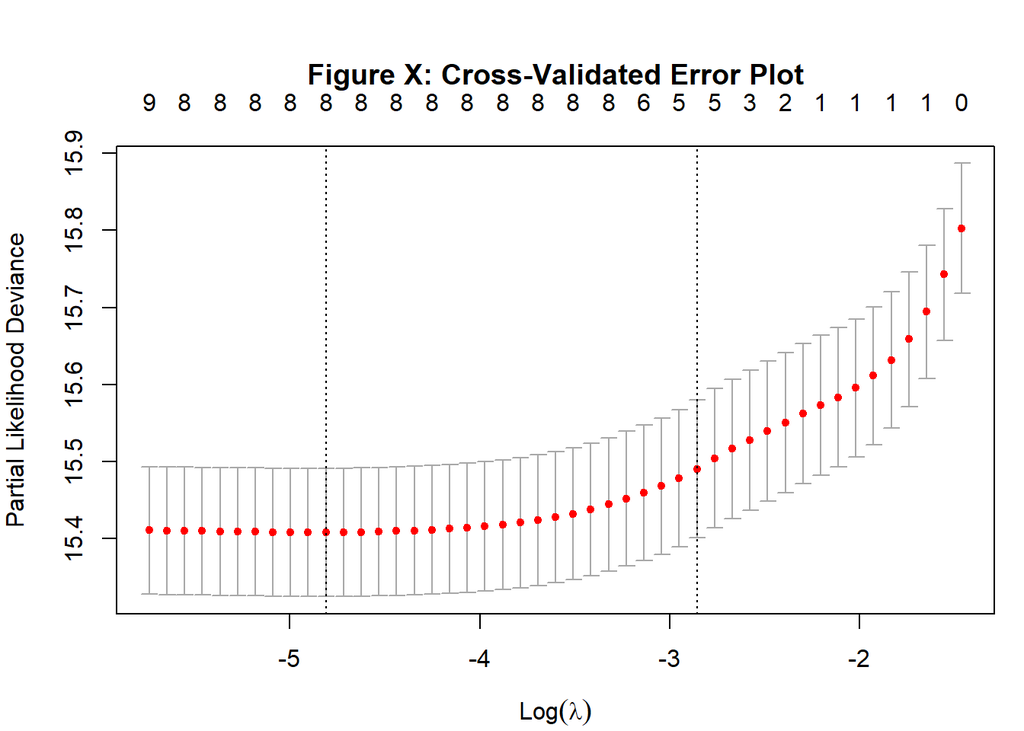

In the plot above, we see the results of our cross-validation with the partial likelihood deviance, a measure of error, on the y-axis, and the natural log of the penalty term on the x-axis. The far-left dashed line represents the log($\lambda$) value associated with the model that produced the minimum cross-validation error. The far-right dashed line represents the log($\lambda$) value associated with the “1se” model that results in a cross-validation error one standard error from the minimum. We choose the “1se” model in this application because it increases the penalization on the model, enforces parsimony, and helps to reduce overfitting of our model on the training data set.

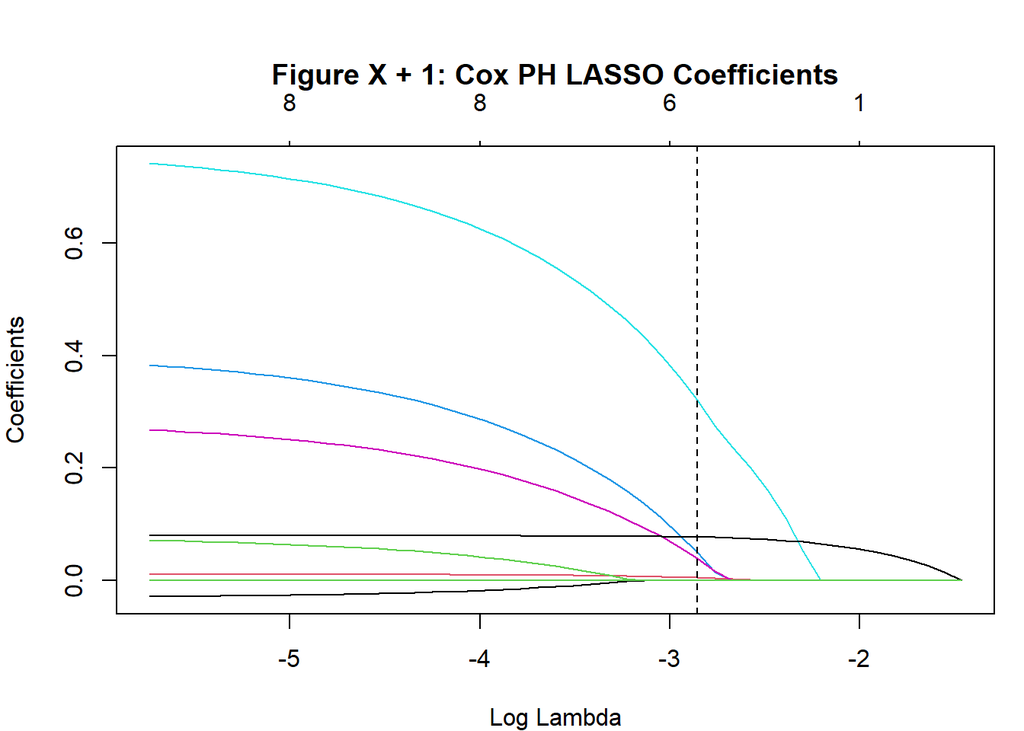

Cox Proportion Hazard LASSO Coefficients (1se)

|  | coef | exp_coef |
| --- | --- | --- |
| year | 0.0000 | 1.0000 |
| age | 0.0048 | 1.0048 |
| meno | 0.0000 | 1.0000 |
| size20-50 | 0.0495 | 1.0508 |
| size>50 | 0.3216 | 1.3793 |
| grade | 0.0386 | 1.0393 |
| nodes | 0.0774 | 1.0805 |
| pgr | 0.0000 | 1.0000 |
| er | 0.0000 | 1.0000 |
| hormon1 | 0.0000 | 1.0000 |
| chemo1 | 0.0000 | 1.0000 |

|  | 2.5 % | 97.5 % |
| --- | --- | --- |
| age | 1.0096113 | 1.0209412 |
| size20-50 | 1.3250933 | 1.7610328 |
| size>50 | 1.7728357 | 2.6497651 |
| grade | 1.1207981 | 1.5335347 |
| nodes | 1.0717882 | 1.0964130 |
| pgr | 0.9993588 | 0.9998718 |
| hormon1 | 0.7818093 | 1.1517154 |
| chemo1 | 0.8503259 | 1.2090508 |

And we find significant effects for age at surgery, size of tumor, differentiation grade, number of positive lymph nodes, and pgr. We find non-significant effects for each of the two treatments of interest.

## Randomized Survival Forest

| time | survival |
| --- | --- |
| 36 | 1.0000000 |
| 45 | 0.9975471 |
| 64 | 0.9975471 |
| 74 | 0.9960829 |
| 97 | 0.9957616 |
| 101 | 0.9942716 |

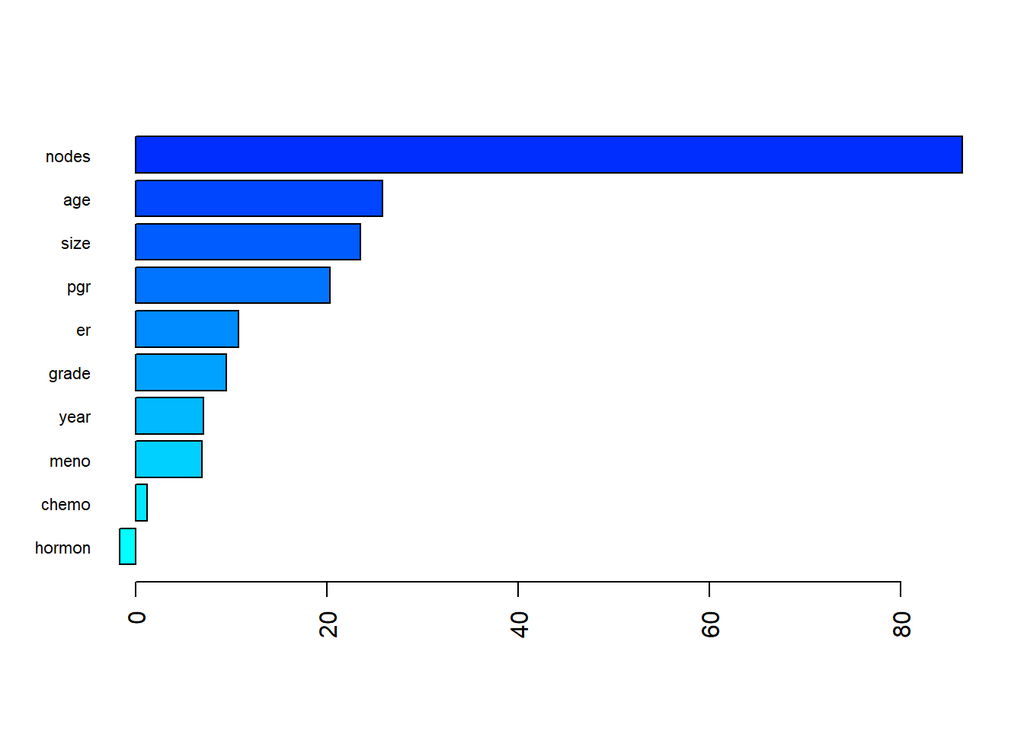

With `ranger` package, we trained the random survival forest (RSF) with training dataset used for survival prediction. As a non-parametric method, there are no parameters in RSF that could be interpreted. The ultimate goal of RSF is to predict the survival probability function of a given data point based on its covariate vector. Compared to semi-parametric Cox-PH model which forces the outcome and the covariates to have a special connection, the RSF makes prediction based on the survival time of training data points that shares similar propensity with the given input data point.

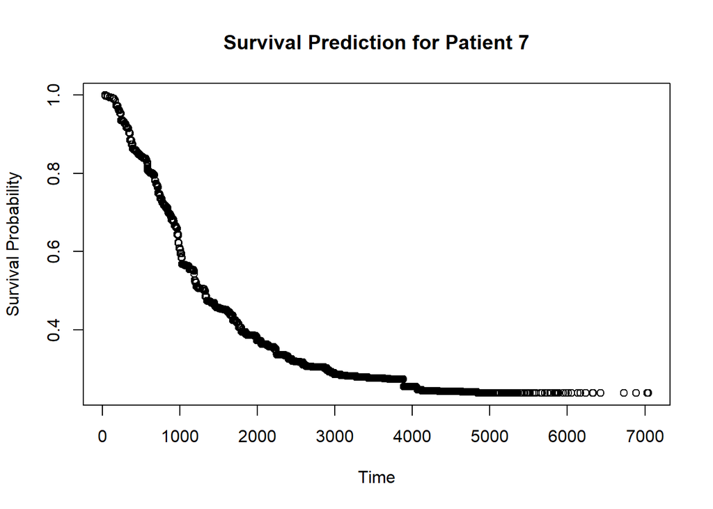

|  | time | survival |
| --- | --- | --- |
| 382 | 1319 | 0.4994471 |
| 383 | 1322 | 0.4994471 |
| 384 | 1323 | 0.4990825 |
| 385 | 1325 | 0.4990825 |
| 386 | 1327 | 0.4990101 |
| 387 | 1331 | 0.4849616 |

|  | year | age | meno | size | grade | nodes | pgr | er | hormon | chemo | dtime | death |
| --- | --- | --- | --- | --- | --- | --- | --- | --- | --- | --- | --- | --- |
| 2463 | 1992 | 69 | 1 | 20-50 | 2 | 8 | 5 | 6 | 1 | 0 | 1869 | 0 |

## Brier Score

First, we calculated the Brier score for the Cox proportional-hazards model.

```
## [1] 0.329
```

The Brier score for the Cox proportional-hazards model is 0.329.

Second, let’s calculated the Brier score for the random survival forest model.

```
## [1] 0.319
```

The Brier score for the random survival forest model is 0.319. The two models have very similar Brier scores. While we did not perform any statistical tests, given how close the two values are, it is fair to conclude that the Cox proportional-hazards model and the random survival forest are comparable in terms of predicting the outcome. However, if the goal of an analysis is inference, the semi-parametric Cox proportional-hazards model would be preferred to the non-parametric random survival forest.

An alternative metric that could be used instead of the Brier score is the area under the receiver operating characteristic curve.

# Discussion

## Conclusions

Hormone therapy and chemotherapy appear to have non-significant treatment effects on outcomes after adjusting for covariates. Tumor size and differentiation grade had the largest magnitude effects on hazard and were significant. The Cox proportional-hazards and random survival forest models performed similarly in predicting the outcome.

Some limitations are that there was a small sample size for the treated, especially when it comes to treatment subgroup of receiving both chemo and hormone therapy (only 1% of samples). Additionally, being non-parametric, there is no valid inference methods for random survival forest with potential bias for estimated individual survival curve. We ignored remission. Additionally, there were some violations in the proportional-hazards assumption for the Cox proportional-hazards model.

## Appendix

Calculating and plotting Schoenfeld residuals.

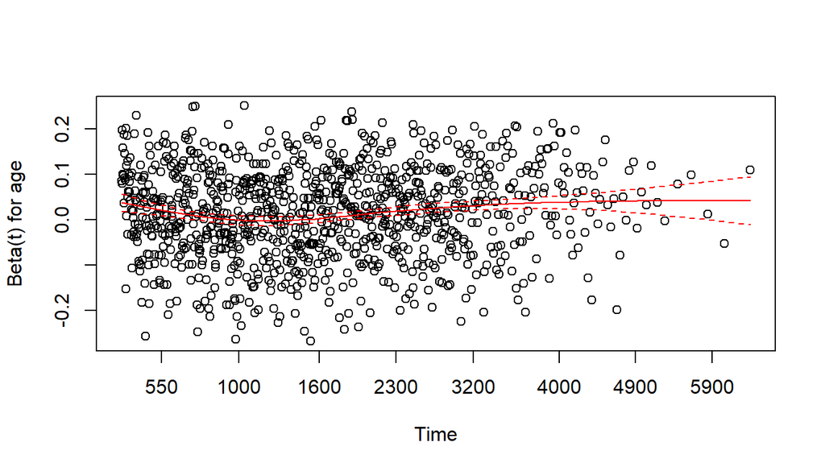

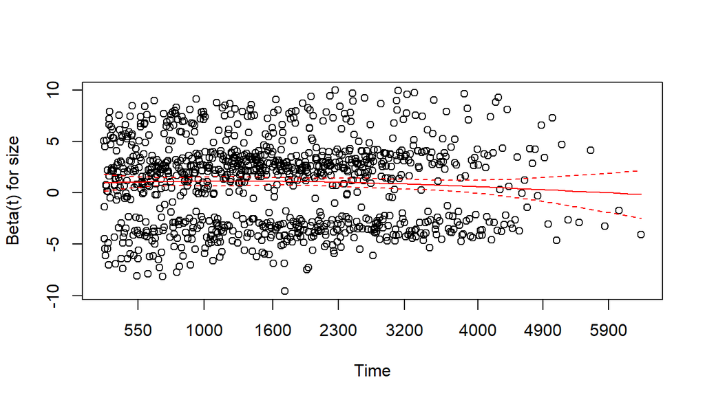

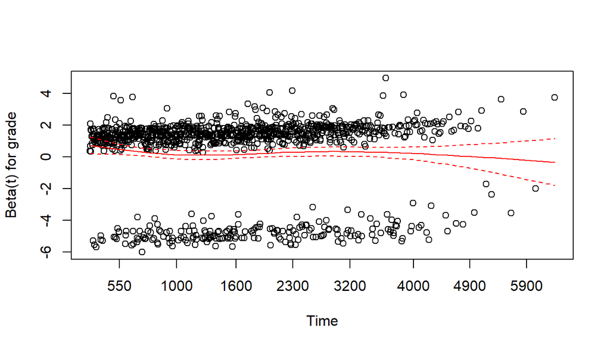

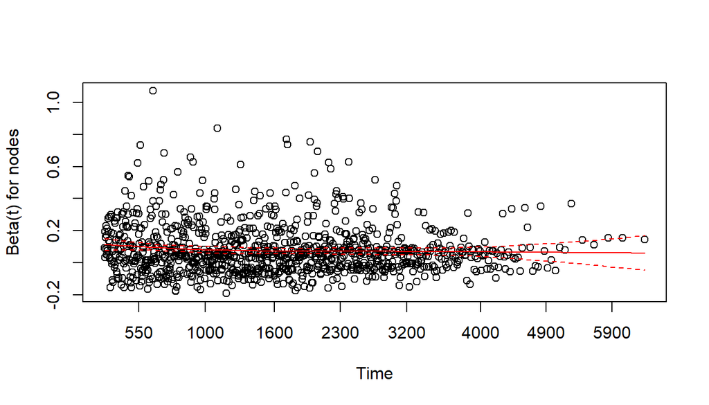

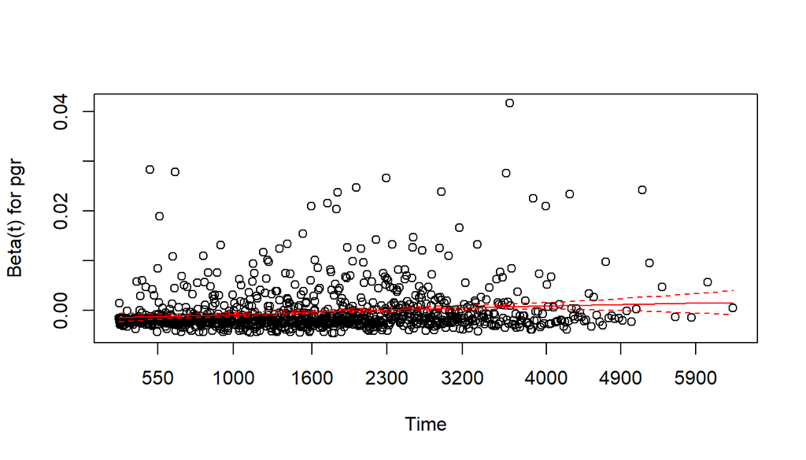

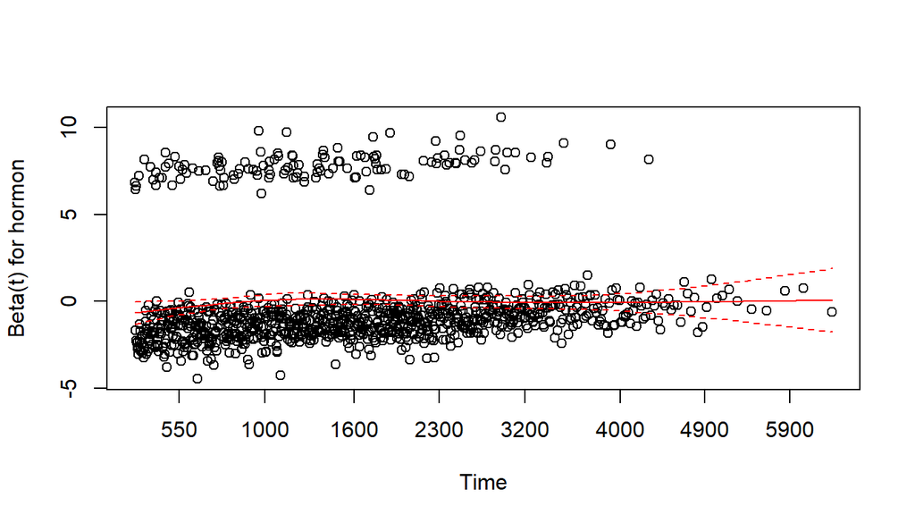

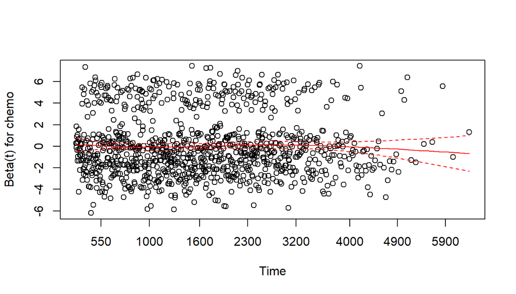

## Supplemental analyses

### Kaplan-Meier Survival Estimate

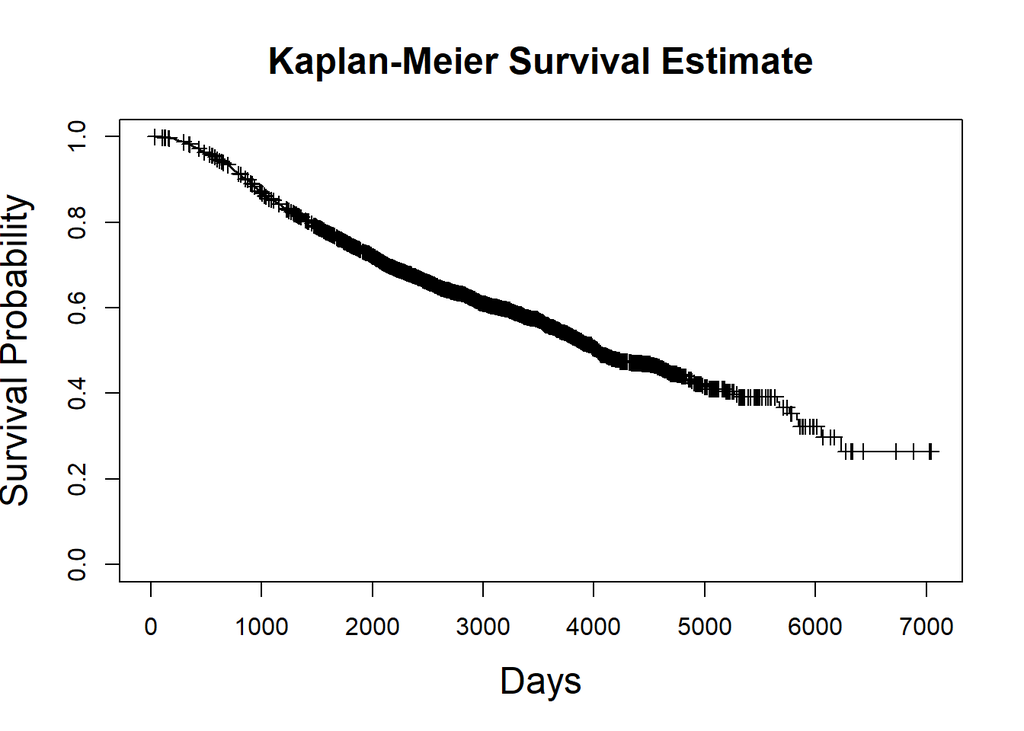

### Log-rank Tests

To answer the research questions of whether hormone treatment and chemotherapy are effective to breast cancer, the initial step is to test whether the survival probability functions of treatment group and control group are identical with log-rank test. In this report, we conducted 3 log-rank tests.

**Hormone Therapy**

First, we test whether hormone therapy is effective. The null hypothesis of this test is $H_0: S_1(t) = S_0(t)$, where $S_1(t)$ is the survival function of hormone treatment group, $S_0(t)$ is the survival function of control group, and the alternative hypothesis is $H_1: S_1(t) \ne S_0(t)$.

Log Rank Test of Hormone Therapy

| hormon | N | obs | exp |
| --- | --- | --- | --- |
| 0 | 2643 | 1113 | 1161.6299 |
| 1 | 339 | 159 | 110.3701 |

The test statistic is 23.7, and the corresponding p-value is $1.133^{-6} \ll 0.05$, thus we reject the null and conclude that we are 95% confident that $S_1(t) \ne S_0(t)$.

[figure not shown]

**Chemotherapy**

Then, we test whether chemotherapy is effective. The null hypothesis of this test is $H_0: S_1(t) = S_0(t)$, similarly, $S_1(t)$ is the survival function of chemo treatment group, $S_0(t)$ is the survival function of control group, and the alternative hypothesis is $H_1: S_1(t) \ne S_0(t)$.

```
## Call:
## survdiff(formula = Surv(dtime, death) ~ chemo, data = rotterdam)
##
##            N Observed Expected (O-E)^2/E (O-E)^2/V
## chemo=0 2402     1014     1024    0.0963     0.495
## chemo=1  580      258      248    0.3977     0.495
##
##  Chisq= 0.5  on 1 degrees of freedom, p= 0.5
```

```
## [1] 0.4818191
```

The test statistic is 0.495, and the corresponding p-value is $0.48 > 0.05$, thus we fail to reject the null and conclude that we are 95% confident that $S_1(t) = S_0(t)$. In other words, the chemotherapy is not effective to the treatment of breast cancer.

[figure not shown]

**Combined Analysis**

After testing the effect of hormone and chemotherapy separately, we are interested in whether there are interaction (or confounding) between the two treatments. Hence, we reassign the data into 4 new treatment groups: 1) receive both hormone and chemotherapy; 2) only receive hormone therapy; 3) only receive chemotherapy; and 4) not receiving both of the therapies.

Then we tested the survival function of these 4 groups with log-rank test. Here, the null hypothesis is $H_0: S_1(t) = S_2(t) = S_3(t) = S_4(t)$, corresponding to the survival function of 4 groups; and the alternative hypothesis is: the survival probability function of 4 groups are not identical.

```
## Call:
## survdiff(formula = Surv(dtime, death) ~ trt_label, data = rotterdam1)
##
##                           N Observed Expected (O-E)^2/E (O-E)^2/V
## trt_label=chemo         552      250    233.7      1.13      1.39
## trt_label=hormon        311      151     96.0     31.45     34.43
## trt_label=hormon+chemo   28        8     14.3      2.79      2.83
## trt_label=none         2091      863    927.9      4.54     16.84
##
##  Chisq= 40.4  on 3 degrees of freedom, p= 9e-09
```

```
## [1] 8.838693e-09
```

The test statistics is 40.4, with p-value $8.84^{-9} \ll 0.05$, then reject the null and conclude that the survival function of 4 groups are not identical. But this result is not very meaningful, because we are more interested in the way they are different.

Consequently, we refer to the survival plot:

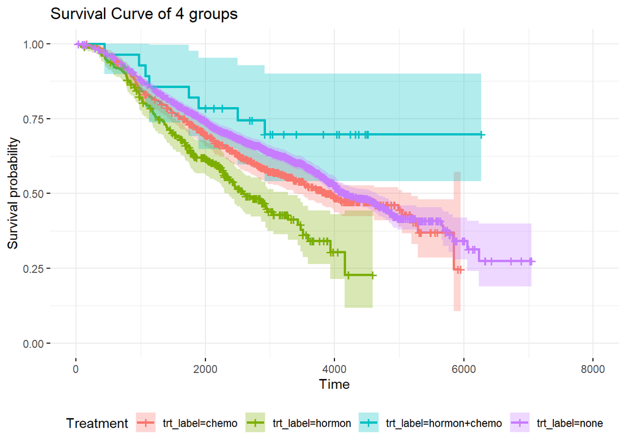

Based on the plot, it seems like: Hormone therapy or Chemotherapy itself cannot improve the survival of breast cancer, while the combination therapy of Hormone + Chemo can improve the survival.

Although it is a very interesting finding, but we should question whether this conclusion is valid. According to the summary data shown below, the sample size of hormone+chemo treatment group is only 28, which accounts for 8% of people who receive hormone therapy, and accounts for 1% of the whole dataset. As a result, the survival curve predicted for this combo treatment group can be unconvincing and biased comparing to other treatment groups, which makes the conclusion drawn above to be invalid.

| Var1 | Freq |
| --- | --- |
| chemo | 552 |
| hormon | 311 |
| hormon+chemo | 28 |
| none | 2091 |

Although the results drawn from the third plot are not reliable, it is still a discovery that should be highlighted by researchers, since it is a common phenomenon biologically that two drugs can perform treatment effect only when taken together. More clinical trials and statistically analyses are suggested to further explore this issue.

Also, the test results of the first two log-ranks tests should be considered carefully for making decisions, because they didn’t adjusted with the baseline covariates, then the observed treatment effects of hormone may be confounded by other covariates.

## References

Simon, Noah et al. “Regularization Paths for Cox’s Proportional Hazards Model via Coordinate Descent.” Journal of statistical software vol. 39,5 (2011): 1-13. doi:10.18637/jss.v039.i05